# h5

Yating Tian

3/1/2020

1. Describe the null hypotheses to which the p-values given in Table 3.4 correspond. Explain what conclusions you can draw based on these p-values. Your explanation should be phrased in terms of sales, TV, radio, and newspaper, rather than in terms of the coefficients of the linear model.

**The null hypothese is that the budgets of the TV, radio and newspaper advertisement have no effect on sale. Based on the p value in the table, we can say that we have enough evidence to reject the null hypothesis of TV and radio, which is we reject that the budgets of the TV, radio advertisement have no effect on sale. But we don’t have the strong evidence to reject that newspaper’s null hypothesis, which means we cannot reject that the budgets of newspaper advertisement have no effect on sale.**

3. Suppose we have a data set with five predictors, X1 = GPA, X2 = IQ, X3 = Gender (1 for Female and 0 for Male), X4 = Interaction between GPA and IQ, and X5 = Interaction between GPA and Gender. The response is starting salary after graduation (in thousands of dollars).Suppose we use least squares to fit the model, and get βˆ0 = 50, βˆ1 = 20, βˆ2 = 0.07, βˆ3 = 35, βˆ4 = 0.01, βˆ5 = −10.
1. Which answer is correct, and why?
1. For a fixed value of IQ and GPA, males earn more on average than females.
2. For a fixed value of IQ and GPA, females earn more on average than males.
3. For a fixed value of IQ and GPA, males earn more on average than females provided that the GPA is high enough.
4. For a fixed value of IQ and GPA, females earn more on average than males provided that the GPA is high enough.

**p_hat_male=50 + 20xGPA + 0.07xIQ + 35xgender(0) + 0.01xGPAxIQ + -10xGPAxgender(0). p_hat_female=50+35xgender(1) + 20xGPA- 10xGPAxgender(1) + 0.07xIQ +0.01xGPAxIQ.narrow down to p_hat_male=50 + 20xGPA + 0.07xIQ+ 0.01xGPAxIQ p_hat_female=85 + 10xGPA + 0.07xIQ +0.01xGPAxIQ. So when p_hap_male:50+20GPA>= p_hat_female 85+10GPA is true, which is when GPA>=3.5, “GPA is high enough” answer iii is correct. when GPA is higher than 3.5 male has higher start salary than female**

2. Predict the salary of a female with IQ of 110 and a GPA of 4.0.

```r
GPA=4.0
IQ=110
female3b=85 + 10*GPA + 0.07*110+0.01*GPA*IQ
female3b
```

```
## [1] 137.1
```

3. True or false: Since the coefficient for the GPA/IQ interaction term is very small, there is very little evidence of an interaction effect. Justify your answer.

**False. we must test the hypothesis that β4=0 and look at the p-value to draw the conclusion that there is very little evidence of an interaction effect of GPA and IQ**

4. I collect a set of data (n = 100 observations) containing a single predictor and a quantitative response. I then fit a linear regression model to the data, as well as a separate cubic regression, i.e. Y = β0 + β1X + β2X2 + β3X3 + .
1. Suppose that the true relationship between X and Y is linear, i.e. Y = β0 + β1X + e. Consider the training residual sum of squares (RSS) for the linear regression, and also the training RSS for the cubic regression. Would we expect one to be lower than the other, would we expect them to be the same, or is there not enough information to tell? Justify your answer.

**The training RSS for the cubic regression might be lower than the the training RSS for the linear regression because the cubic regression have more predictors**

2. Answer (a) using test rather than training RSS.

**because more predictors might lead to the overfiting, cubic regression get higher test RSS than the liner regression**

3. Suppose that the true relationship between X and Y is not linear,but we don’t know how far it is from linear. Consider the training RSS for the linear regression, and also the training RSS for the cubic regression. Would we expect one to be lower than the other, would we expect them to be the same, or is there not enough information to tell? Justify your answer.

**cubic regression has lower train RSS than the linear fit because it has higher flexibility**

4. Answer (c) using test rather than training RSS.

**Because of the bias-variance trade off, we can not tell which level of flexibility fits data better.**

15. This problem involves the Boston data set, which we saw in the lab for this chapter. We will now try to predict per capita crime rate using the other variables in this data set. In other words, per capita crime rate is the response, and the other variables are the predictors.

```r
#(a) For each predictor, fit a simple linear regression model to predict the response. Describe your results. In which of the models is there a statistically significant association between the predictor and the response? Create some plots to back up your assertions.
library(MASS)
library(tidyverse)
library(reshape2)
view(Boston)
zn=lm(Boston$crim~Boston$zn)
indus=lm(Boston$crim~Boston$indus)
chas=lm(Boston$crim~Boston$chas)
nox=lm(Boston$crim~Boston$nox)
rm=lm(Boston$crim~Boston$rm)
age=lm(Boston$crim~Boston$age)
dis=lm(Boston$crim~Boston$dis)
rad=lm(Boston$crim~Boston$rad)
tax=lm(Boston$crim~Boston$tax)
ptratio=lm(Boston$crim~Boston$ptratio)
black=lm(Boston$crim~Boston$black)
lstat=lm(Boston$crim~Boston$lstat)
medv=lm(Boston$crim~Boston$medv)
summary(zn)
```

```
##
## Call:
## lm(formula = Boston$crim ~ Boston$zn)
##
## Residuals:
##    Min     1Q Median     3Q    Max
## -4.429 -4.222 -2.620  1.250 84.523
##
## Coefficients:
##             Estimate Std. Error t value Pr(>|t|)
## (Intercept)  4.45369    0.41722  10.675  < 2e-16 ***
## Boston$zn   -0.07393    0.01609  -4.594 5.51e-06 ***
## ---
## Signif. codes:  0 '***' 0.001 '**' 0.01 '*' 0.05 '.' 0.1 ' ' 1
##
## Residual standard error: 8.435 on 504 degrees of freedom
## Multiple R-squared:  0.04019,    Adjusted R-squared:  0.03828
## F-statistic:  21.1 on 1 and 504 DF,  p-value: 5.506e-06
```

```r
summary(indus)
```

```
##
## Call:
## lm(formula = Boston$crim ~ Boston$indus)
##
## Residuals:
##     Min      1Q  Median      3Q     Max
## -11.972  -2.698  -0.736   0.712  81.813
##
## Coefficients:
##              Estimate Std. Error t value Pr(>|t|)
## (Intercept)  -2.06374    0.66723  -3.093  0.00209 **
## Boston$indus  0.50978    0.05102   9.991  < 2e-16 ***
## ---
## Signif. codes:  0 '***' 0.001 '**' 0.01 '*' 0.05 '.' 0.1 ' ' 1
##
## Residual standard error: 7.866 on 504 degrees of freedom
## Multiple R-squared:  0.1653, Adjusted R-squared:  0.1637
## F-statistic: 99.82 on 1 and 504 DF,  p-value: < 2.2e-16
```

```r
summary(chas)
```

```
##
## Call:
## lm(formula = Boston$crim ~ Boston$chas)
##
## Residuals:
##    Min     1Q Median     3Q    Max
## -3.738 -3.661 -3.435  0.018 85.232
##
## Coefficients:
##             Estimate Std. Error t value Pr(>|t|)
## (Intercept)   3.7444     0.3961   9.453   <2e-16 ***
## Boston$chas  -1.8928     1.5061  -1.257    0.209
## ---
## Signif. codes:  0 '***' 0.001 '**' 0.01 '*' 0.05 '.' 0.1 ' ' 1
##
## Residual standard error: 8.597 on 504 degrees of freedom
## Multiple R-squared:  0.003124,   Adjusted R-squared:  0.001146
## F-statistic: 1.579 on 1 and 504 DF,  p-value: 0.2094
```

```r
summary(nox)
```

```
##
## Call:
## lm(formula = Boston$crim ~ Boston$nox)
##
## Residuals:
##     Min      1Q  Median      3Q     Max
## -12.371  -2.738  -0.974   0.559  81.728
##
## Coefficients:
##             Estimate Std. Error t value Pr(>|t|)
## (Intercept)  -13.720      1.699  -8.073 5.08e-15 ***
## Boston$nox    31.249      2.999  10.419  < 2e-16 ***
## ---
## Signif. codes:  0 '***' 0.001 '**' 0.01 '*' 0.05 '.' 0.1 ' ' 1
##
## Residual standard error: 7.81 on 504 degrees of freedom
## Multiple R-squared:  0.1772, Adjusted R-squared:  0.1756
## F-statistic: 108.6 on 1 and 504 DF,  p-value: < 2.2e-16
```

```r
summary(rm)
```

```
##
## Call:
## lm(formula = Boston$crim ~ Boston$rm)
##
## Residuals:
##    Min     1Q Median     3Q    Max
## -6.604 -3.952 -2.654  0.989 87.197
##
## Coefficients:
##             Estimate Std. Error t value Pr(>|t|)
## (Intercept)   20.482      3.365   6.088 2.27e-09 ***
## Boston$rm     -2.684      0.532  -5.045 6.35e-07 ***
## ---
## Signif. codes:  0 '***' 0.001 '**' 0.01 '*' 0.05 '.' 0.1 ' ' 1
##
## Residual standard error: 8.401 on 504 degrees of freedom
## Multiple R-squared:  0.04807,    Adjusted R-squared:  0.04618
## F-statistic: 25.45 on 1 and 504 DF,  p-value: 6.347e-07
```

```r
summary(age)
```

```
##
## Call:
## lm(formula = Boston$crim ~ Boston$age)
##
## Residuals:
##    Min     1Q Median     3Q    Max
## -6.789 -4.257 -1.230  1.527 82.849
##
## Coefficients:
##             Estimate Std. Error t value Pr(>|t|)
## (Intercept) -3.77791    0.94398  -4.002 7.22e-05 ***
## Boston$age   0.10779    0.01274   8.463 2.85e-16 ***
## ---
## Signif. codes:  0 '***' 0.001 '**' 0.01 '*' 0.05 '.' 0.1 ' ' 1
##
## Residual standard error: 8.057 on 504 degrees of freedom
## Multiple R-squared:  0.1244, Adjusted R-squared:  0.1227
## F-statistic: 71.62 on 1 and 504 DF,  p-value: 2.855e-16
```

```r
summary(dis)
```

```
##
## Call:
## lm(formula = Boston$crim ~ Boston$dis)
##
## Residuals:
##    Min     1Q Median     3Q    Max
## -6.708 -4.134 -1.527  1.516 81.674
##
## Coefficients:
##             Estimate Std. Error t value Pr(>|t|)
## (Intercept)   9.4993     0.7304  13.006   <2e-16 ***
## Boston$dis   -1.5509     0.1683  -9.213   <2e-16 ***
## ---
## Signif. codes:  0 '***' 0.001 '**' 0.01 '*' 0.05 '.' 0.1 ' ' 1
##
## Residual standard error: 7.965 on 504 degrees of freedom
## Multiple R-squared:  0.1441, Adjusted R-squared:  0.1425
## F-statistic: 84.89 on 1 and 504 DF,  p-value: < 2.2e-16
```

```r
summary(rad)
```

```
##
## Call:
## lm(formula = Boston$crim ~ Boston$rad)
##
## Residuals:
##     Min      1Q  Median      3Q     Max
## -10.164  -1.381  -0.141   0.660  76.433
##
## Coefficients:
##             Estimate Std. Error t value Pr(>|t|)
## (Intercept) -2.28716    0.44348  -5.157 3.61e-07 ***
## Boston$rad   0.61791    0.03433  17.998  < 2e-16 ***
## ---
## Signif. codes:  0 '***' 0.001 '**' 0.01 '*' 0.05 '.' 0.1 ' ' 1
##
## Residual standard error: 6.718 on 504 degrees of freedom
## Multiple R-squared:  0.3913, Adjusted R-squared:   0.39
## F-statistic: 323.9 on 1 and 504 DF,  p-value: < 2.2e-16
```

```r
summary(tax)
```

```
##
## Call:
## lm(formula = Boston$crim ~ Boston$tax)
##
## Residuals:
##     Min      1Q  Median      3Q     Max
## -12.513  -2.738  -0.194   1.065  77.696
##
## Coefficients:
##              Estimate Std. Error t value Pr(>|t|)
## (Intercept) -8.528369   0.815809  -10.45   <2e-16 ***
## Boston$tax   0.029742   0.001847   16.10   <2e-16 ***
## ---
## Signif. codes:  0 '***' 0.001 '**' 0.01 '*' 0.05 '.' 0.1 ' ' 1
##
## Residual standard error: 6.997 on 504 degrees of freedom
## Multiple R-squared:  0.3396, Adjusted R-squared:  0.3383
## F-statistic: 259.2 on 1 and 504 DF,  p-value: < 2.2e-16
```

```r
summary(ptratio)
```

```
##
## Call:
## lm(formula = Boston$crim ~ Boston$ptratio)
##
## Residuals:
##    Min     1Q Median     3Q    Max
## -7.654 -3.985 -1.912  1.825 83.353
##
## Coefficients:
##                Estimate Std. Error t value Pr(>|t|)
## (Intercept)    -17.6469     3.1473  -5.607 3.40e-08 ***
## Boston$ptratio   1.1520     0.1694   6.801 2.94e-11 ***
## ---
## Signif. codes:  0 '***' 0.001 '**' 0.01 '*' 0.05 '.' 0.1 ' ' 1
##
## Residual standard error: 8.24 on 504 degrees of freedom
## Multiple R-squared:  0.08407,    Adjusted R-squared:  0.08225
## F-statistic: 46.26 on 1 and 504 DF,  p-value: 2.943e-11
```

```r
summary(black)
```

```
##
## Call:
## lm(formula = Boston$crim ~ Boston$black)
##
## Residuals:
##     Min      1Q  Median      3Q     Max
## -13.756  -2.299  -2.095  -1.296  86.822
##
## Coefficients:
##               Estimate Std. Error t value Pr(>|t|)
## (Intercept)  16.553529   1.425903  11.609   <2e-16 ***
## Boston$black -0.036280   0.003873  -9.367   <2e-16 ***
## ---
## Signif. codes:  0 '***' 0.001 '**' 0.01 '*' 0.05 '.' 0.1 ' ' 1
##
## Residual standard error: 7.946 on 504 degrees of freedom
## Multiple R-squared:  0.1483, Adjusted R-squared:  0.1466
## F-statistic: 87.74 on 1 and 504 DF,  p-value: < 2.2e-16
```

```r
summary(lstat)
```

```
##
## Call:
## lm(formula = Boston$crim ~ Boston$lstat)
##
## Residuals:
##     Min      1Q  Median      3Q     Max
## -13.925  -2.822  -0.664   1.079  82.862
##
## Coefficients:
##              Estimate Std. Error t value Pr(>|t|)
## (Intercept)  -3.33054    0.69376  -4.801 2.09e-06 ***
## Boston$lstat  0.54880    0.04776  11.491  < 2e-16 ***
## ---
## Signif. codes:  0 '***' 0.001 '**' 0.01 '*' 0.05 '.' 0.1 ' ' 1
##
## Residual standard error: 7.664 on 504 degrees of freedom
## Multiple R-squared:  0.2076, Adjusted R-squared:  0.206
## F-statistic:   132 on 1 and 504 DF,  p-value: < 2.2e-16
```

```r
summary(medv)
```

```
##
## Call:
## lm(formula = Boston$crim ~ Boston$medv)
##
## Residuals:
##    Min     1Q Median     3Q    Max
## -9.071 -4.022 -2.343  1.298 80.957
##
## Coefficients:
##             Estimate Std. Error t value Pr(>|t|)
## (Intercept) 11.79654    0.93419   12.63   <2e-16 ***
## Boston$medv -0.36316    0.03839   -9.46   <2e-16 ***
## ---
## Signif. codes:  0 '***' 0.001 '**' 0.01 '*' 0.05 '.' 0.1 ' ' 1
##
## Residual standard error: 7.934 on 504 degrees of freedom
## Multiple R-squared:  0.1508, Adjusted R-squared:  0.1491
## F-statistic: 89.49 on 1 and 504 DF,  p-value: < 2.2e-16
```

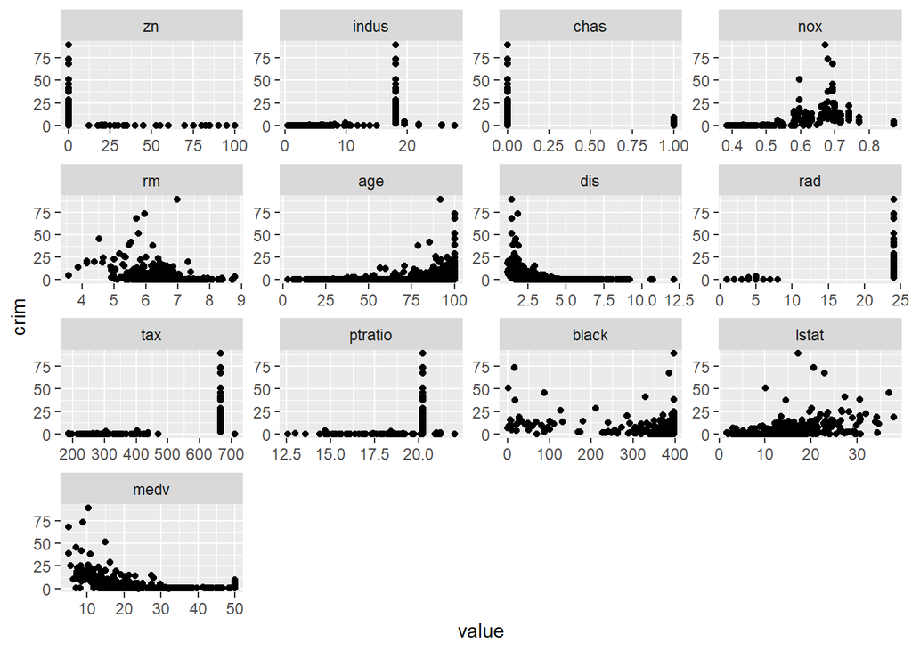

```r
#Based on the p_values in the summaries, every prdictor except chas has relationship with crim, which the p value of those prdictor is lower than 0.05.
bos <- melt(Boston, id="crim")
ggplot(bos, aes(x=value, y=crim)) +
  facet_wrap(~variable, scales="free") +
  geom_point()
```

```r
#(b) Fit a multiple regression model to predict the response using all of the predictors. Describe your results. For which predictors can we reject the null hypothesis H0 : βj = 0?

all=lm(crim~.,data=Boston)
summary(all)
```

```
##
## Call:
## lm(formula = crim ~ ., data = Boston)
##
## Residuals:
##    Min     1Q Median     3Q    Max
## -9.924 -2.120 -0.353  1.019 75.051
##
## Coefficients:
##               Estimate Std. Error t value Pr(>|t|)
## (Intercept)  17.033228   7.234903   2.354 0.018949 *
## zn            0.044855   0.018734   2.394 0.017025 *
## indus        -0.063855   0.083407  -0.766 0.444294
## chas         -0.749134   1.180147  -0.635 0.525867
## nox         -10.313535   5.275536  -1.955 0.051152 .
## rm            0.430131   0.612830   0.702 0.483089
## age           0.001452   0.017925   0.081 0.935488
## dis          -0.987176   0.281817  -3.503 0.000502 ***
## rad           0.588209   0.088049   6.680 6.46e-11 ***
## tax          -0.003780   0.005156  -0.733 0.463793
## ptratio      -0.271081   0.186450  -1.454 0.146611
## black        -0.007538   0.003673  -2.052 0.040702 *
## lstat         0.126211   0.075725   1.667 0.096208 .
## medv         -0.198887   0.060516  -3.287 0.001087 **
## ---
## Signif. codes:  0 '***' 0.001 '**' 0.01 '*' 0.05 '.' 0.1 ' ' 1
##
## Residual standard error: 6.439 on 492 degrees of freedom
## Multiple R-squared:  0.454,  Adjusted R-squared:  0.4396
## F-statistic: 31.47 on 13 and 492 DF,  p-value: < 2.2e-16
```

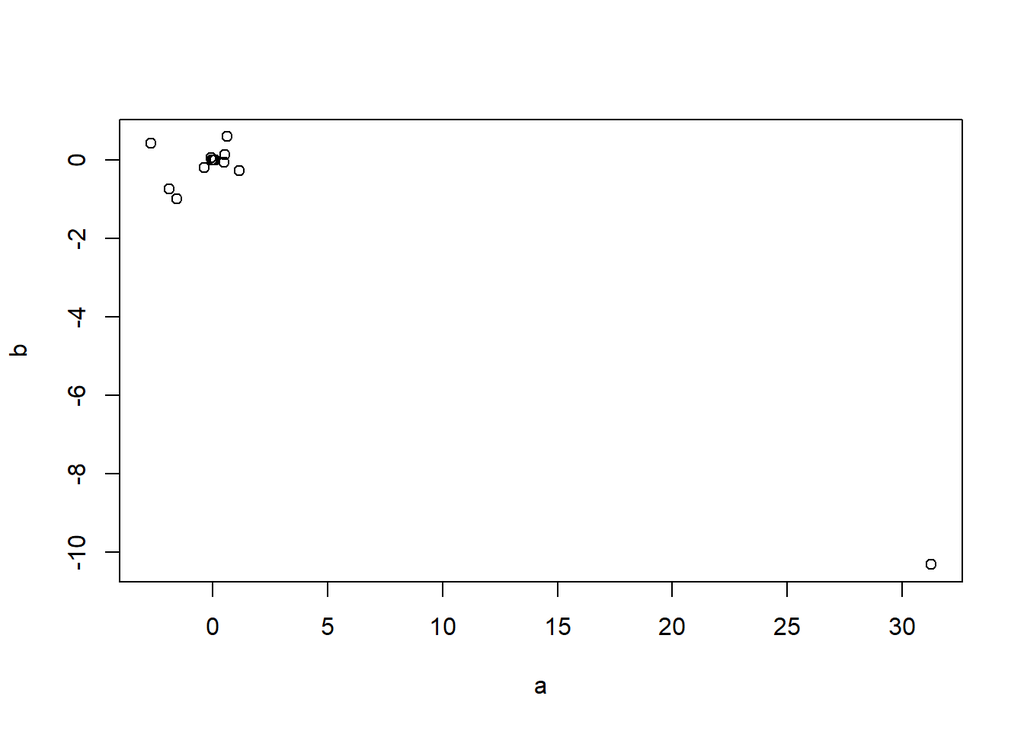

```r
# we can reject that prdictor zn,dis, rad,black, and medv, which reject their null hypothesis H0 : βj = 0.

#(c) How do your results from (a) compare to your results from (b)? Create a plot displaying the univariate regression coefficients from (a) on the x-axis, and the multiple regression coefficients from (b) on the y-axis. That is, each predictor is displayed as a single point in the plot. Its coefficient in a simple linear regression model is shown on the x-axis, and its coefficient estimate in the multiple linear regression model is shown on the y-axis.

#the result of (a),(b) is different.
a = c(coefficients(zn)[2],
      coefficients(indus)[2],
      coefficients(chas)[2],
      coefficients(nox)[2],
      coefficients(rm)[2],
      coefficients(age)[2],
      coefficients(dis)[2],
      coefficients(rad)[2],
      coefficients(tax)[2],
      coefficients(ptratio)[2],
      coefficients(black)[2],
      coefficients(lstat)[2],
      coefficients(medv)[2])
b = coefficients(all)[2:14]
plot(a,b)
```

```r
#(d) Is there evidence of non-linear association between any of the predictors and the response? To answer this question, for each predictor X, fit a model of the form Y = β0 + β1X + β2X2 + β3X3 + e.
dzn = lm(Boston$crim~poly(Boston$zn,3))
summary(dzn)
```

```
##
## Call:
## lm(formula = Boston$crim ~ poly(Boston$zn, 3))
##
## Residuals:
##    Min     1Q Median     3Q    Max
## -4.821 -4.614 -1.294  0.473 84.130
##
## Coefficients:
##                     Estimate Std. Error t value Pr(>|t|)
## (Intercept)           3.6135     0.3722   9.709  < 2e-16 ***
## poly(Boston$zn, 3)1 -38.7498     8.3722  -4.628  4.7e-06 ***
## poly(Boston$zn, 3)2  23.9398     8.3722   2.859  0.00442 **
## poly(Boston$zn, 3)3 -10.0719     8.3722  -1.203  0.22954
## ---
## Signif. codes:  0 '***' 0.001 '**' 0.01 '*' 0.05 '.' 0.1 ' ' 1
##
## Residual standard error: 8.372 on 502 degrees of freedom
## Multiple R-squared:  0.05824,    Adjusted R-squared:  0.05261
## F-statistic: 10.35 on 3 and 502 DF,  p-value: 1.281e-06
```

```r
dindus= lm(Boston$crim~poly(Boston$indus,3))
summary(dindus)
```

```
##
## Call:
## lm(formula = Boston$crim ~ poly(Boston$indus, 3))
##
## Residuals:
##    Min     1Q Median     3Q    Max
## -8.278 -2.514  0.054  0.764 79.713
##
## Coefficients:
##                        Estimate Std. Error t value Pr(>|t|)
## (Intercept)               3.614      0.330  10.950  < 2e-16 ***
## poly(Boston$indus, 3)1   78.591      7.423  10.587  < 2e-16 ***
## poly(Boston$indus, 3)2  -24.395      7.423  -3.286  0.00109 **
## poly(Boston$indus, 3)3  -54.130      7.423  -7.292  1.2e-12 ***
## ---
## Signif. codes:  0 '***' 0.001 '**' 0.01 '*' 0.05 '.' 0.1 ' ' 1
##
## Residual standard error: 7.423 on 502 degrees of freedom
## Multiple R-squared:  0.2597, Adjusted R-squared:  0.2552
## F-statistic: 58.69 on 3 and 502 DF,  p-value: < 2.2e-16
```

```r
dnox = lm(Boston$crim~poly(Boston$nox,3))
summary(dnox)
```

```
##
## Call:
## lm(formula = Boston$crim ~ poly(Boston$nox, 3))
##
## Residuals:
##    Min     1Q Median     3Q    Max
## -9.110 -2.068 -0.255  0.739 78.302
##
## Coefficients:
##                      Estimate Std. Error t value Pr(>|t|)
## (Intercept)            3.6135     0.3216  11.237  < 2e-16 ***
## poly(Boston$nox, 3)1  81.3720     7.2336  11.249  < 2e-16 ***
## poly(Boston$nox, 3)2 -28.8286     7.2336  -3.985 7.74e-05 ***
## poly(Boston$nox, 3)3 -60.3619     7.2336  -8.345 6.96e-16 ***
## ---
## Signif. codes:  0 '***' 0.001 '**' 0.01 '*' 0.05 '.' 0.1 ' ' 1
##
## Residual standard error: 7.234 on 502 degrees of freedom
## Multiple R-squared:  0.297,  Adjusted R-squared:  0.2928
## F-statistic: 70.69 on 3 and 502 DF,  p-value: < 2.2e-16
```

```r
drm= lm(Boston$crim~poly(Boston$rm,3))
summary(drm)
```

```
##
## Call:
## lm(formula = Boston$crim ~ poly(Boston$rm, 3))
##
## Residuals:
##     Min      1Q  Median      3Q     Max
## -18.485  -3.468  -2.221  -0.015  87.219
##
## Coefficients:
##                     Estimate Std. Error t value Pr(>|t|)
## (Intercept)           3.6135     0.3703   9.758  < 2e-16 ***
## poly(Boston$rm, 3)1 -42.3794     8.3297  -5.088 5.13e-07 ***
## poly(Boston$rm, 3)2  26.5768     8.3297   3.191  0.00151 **
## poly(Boston$rm, 3)3  -5.5103     8.3297  -0.662  0.50858
## ---
## Signif. codes:  0 '***' 0.001 '**' 0.01 '*' 0.05 '.' 0.1 ' ' 1
##
## Residual standard error: 8.33 on 502 degrees of freedom
## Multiple R-squared:  0.06779,    Adjusted R-squared:  0.06222
## F-statistic: 12.17 on 3 and 502 DF,  p-value: 1.067e-07
```

```r
dage = lm(Boston$crim~poly(Boston$age,3))
summary(dage)
```

```
##
## Call:
## lm(formula = Boston$crim ~ poly(Boston$age, 3))
##
## Residuals:
##    Min     1Q Median     3Q    Max
## -9.762 -2.673 -0.516  0.019 82.842
##
## Coefficients:
##                      Estimate Std. Error t value Pr(>|t|)
## (Intercept)            3.6135     0.3485  10.368  < 2e-16 ***
## poly(Boston$age, 3)1  68.1820     7.8397   8.697  < 2e-16 ***
## poly(Boston$age, 3)2  37.4845     7.8397   4.781 2.29e-06 ***
## poly(Boston$age, 3)3  21.3532     7.8397   2.724  0.00668 **
## ---
## Signif. codes:  0 '***' 0.001 '**' 0.01 '*' 0.05 '.' 0.1 ' ' 1
##
## Residual standard error: 7.84 on 502 degrees of freedom
## Multiple R-squared:  0.1742, Adjusted R-squared:  0.1693
## F-statistic: 35.31 on 3 and 502 DF,  p-value: < 2.2e-16
```

```r
ddis= lm(Boston$crim~poly(Boston$dis,3))
summary(ddis)
```

```
##
## Call:
## lm(formula = Boston$crim ~ poly(Boston$dis, 3))
##
## Residuals:
##     Min      1Q  Median      3Q     Max
## -10.757  -2.588   0.031   1.267  76.378
##
## Coefficients:
##                      Estimate Std. Error t value Pr(>|t|)
## (Intercept)            3.6135     0.3259  11.087  < 2e-16 ***
## poly(Boston$dis, 3)1 -73.3886     7.3315 -10.010  < 2e-16 ***
## poly(Boston$dis, 3)2  56.3730     7.3315   7.689 7.87e-14 ***
## poly(Boston$dis, 3)3 -42.6219     7.3315  -5.814 1.09e-08 ***
## ---
## Signif. codes:  0 '***' 0.001 '**' 0.01 '*' 0.05 '.' 0.1 ' ' 1
##
## Residual standard error: 7.331 on 502 degrees of freedom
## Multiple R-squared:  0.2778, Adjusted R-squared:  0.2735
## F-statistic: 64.37 on 3 and 502 DF,  p-value: < 2.2e-16
```

```r
drad = lm(Boston$crim~poly(Boston$rad,3))
summary(drad)
```

```
##
## Call:
## lm(formula = Boston$crim ~ poly(Boston$rad, 3))
##
## Residuals:
##     Min      1Q  Median      3Q     Max
## -10.381  -0.412  -0.269   0.179  76.217
##
## Coefficients:
##                      Estimate Std. Error t value Pr(>|t|)
## (Intercept)            3.6135     0.2971  12.164  < 2e-16 ***
## poly(Boston$rad, 3)1 120.9074     6.6824  18.093  < 2e-16 ***
## poly(Boston$rad, 3)2  17.4923     6.6824   2.618  0.00912 **
## poly(Boston$rad, 3)3   4.6985     6.6824   0.703  0.48231
## ---
## Signif. codes:  0 '***' 0.001 '**' 0.01 '*' 0.05 '.' 0.1 ' ' 1
##
## Residual standard error: 6.682 on 502 degrees of freedom
## Multiple R-squared:    0.4,  Adjusted R-squared:  0.3965
## F-statistic: 111.6 on 3 and 502 DF,  p-value: < 2.2e-16
```

```r
dtax= lm(Boston$crim~poly(Boston$tax,3))
summary(dtax)
```

```
##
## Call:
## lm(formula = Boston$crim ~ poly(Boston$tax, 3))
##
## Residuals:
##     Min      1Q  Median      3Q     Max
## -13.273  -1.389   0.046   0.536  76.950
##
## Coefficients:
##                      Estimate Std. Error t value Pr(>|t|)
## (Intercept)            3.6135     0.3047  11.860  < 2e-16 ***
## poly(Boston$tax, 3)1 112.6458     6.8537  16.436  < 2e-16 ***
## poly(Boston$tax, 3)2  32.0873     6.8537   4.682 3.67e-06 ***
## poly(Boston$tax, 3)3  -7.9968     6.8537  -1.167    0.244
## ---
## Signif. codes:  0 '***' 0.001 '**' 0.01 '*' 0.05 '.' 0.1 ' ' 1
##
## Residual standard error: 6.854 on 502 degrees of freedom
## Multiple R-squared:  0.3689, Adjusted R-squared:  0.3651
## F-statistic:  97.8 on 3 and 502 DF,  p-value: < 2.2e-16
```

```r
dptratio= lm(Boston$crim~poly(Boston$ptratio,3))
summary(dptratio)
```

```
##
## Call:
## lm(formula = Boston$crim ~ poly(Boston$ptratio, 3))
##
## Residuals:
##    Min     1Q Median     3Q    Max
## -6.833 -4.146 -1.655  1.408 82.697
##
## Coefficients:
##                          Estimate Std. Error t value Pr(>|t|)
## (Intercept)                 3.614      0.361  10.008  < 2e-16 ***
## poly(Boston$ptratio, 3)1   56.045      8.122   6.901 1.57e-11 ***
## poly(Boston$ptratio, 3)2   24.775      8.122   3.050  0.00241 **
## poly(Boston$ptratio, 3)3  -22.280      8.122  -2.743  0.00630 **
## ---
## Signif. codes:  0 '***' 0.001 '**' 0.01 '*' 0.05 '.' 0.1 ' ' 1
##
## Residual standard error: 8.122 on 502 degrees of freedom
## Multiple R-squared:  0.1138, Adjusted R-squared:  0.1085
## F-statistic: 21.48 on 3 and 502 DF,  p-value: 4.171e-13
```

```r
dblack= lm(Boston$crim~poly(Boston$black,3))
summary(dblack)
```

```
##
## Call:
## lm(formula = Boston$crim ~ poly(Boston$black, 3))
##
## Residuals:
##     Min      1Q  Median      3Q     Max
## -13.096  -2.343  -2.128  -1.439  86.790
##
## Coefficients:
##                        Estimate Std. Error t value Pr(>|t|)
## (Intercept)              3.6135     0.3536  10.218   <2e-16 ***
## poly(Boston$black, 3)1 -74.4312     7.9546  -9.357   <2e-16 ***
## poly(Boston$black, 3)2   5.9264     7.9546   0.745    0.457
## poly(Boston$black, 3)3  -4.8346     7.9546  -0.608    0.544
## ---
## Signif. codes:  0 '***' 0.001 '**' 0.01 '*' 0.05 '.' 0.1 ' ' 1
##
## Residual standard error: 7.955 on 502 degrees of freedom
## Multiple R-squared:  0.1498, Adjusted R-squared:  0.1448
## F-statistic: 29.49 on 3 and 502 DF,  p-value: < 2.2e-16
```

```r
dlstat = lm(Boston$crim~poly(Boston$lstat,3))
summary(dlstat)
```

```
##
## Call:
## lm(formula = Boston$crim ~ poly(Boston$lstat, 3))
##
## Residuals:
##     Min      1Q  Median      3Q     Max
## -15.234  -2.151  -0.486   0.066  83.353
##
## Coefficients:
##                        Estimate Std. Error t value Pr(>|t|)
## (Intercept)              3.6135     0.3392  10.654   <2e-16 ***
## poly(Boston$lstat, 3)1  88.0697     7.6294  11.543   <2e-16 ***
## poly(Boston$lstat, 3)2  15.8882     7.6294   2.082   0.0378 *
## poly(Boston$lstat, 3)3 -11.5740     7.6294  -1.517   0.1299
## ---
## Signif. codes:  0 '***' 0.001 '**' 0.01 '*' 0.05 '.' 0.1 ' ' 1
##
## Residual standard error: 7.629 on 502 degrees of freedom
## Multiple R-squared:  0.2179, Adjusted R-squared:  0.2133
## F-statistic: 46.63 on 3 and 502 DF,  p-value: < 2.2e-16
```

```r
dmedv= lm(Boston$crim~poly(Boston$medv,3))
summary(dmedv)
```

```
##
## Call:
## lm(formula = Boston$crim ~ poly(Boston$medv, 3))
##
## Residuals:
##     Min      1Q  Median      3Q     Max
## -24.427  -1.976  -0.437   0.439  73.655
##
## Coefficients:
##                       Estimate Std. Error t value Pr(>|t|)
## (Intercept)              3.614      0.292  12.374  < 2e-16 ***
## poly(Boston$medv, 3)1  -75.058      6.569 -11.426  < 2e-16 ***
## poly(Boston$medv, 3)2   88.086      6.569  13.409  < 2e-16 ***
## poly(Boston$medv, 3)3  -48.033      6.569  -7.312 1.05e-12 ***
## ---
## Signif. codes:  0 '***' 0.001 '**' 0.01 '*' 0.05 '.' 0.1 ' ' 1
##
## Residual standard error: 6.569 on 502 degrees of freedom
## Multiple R-squared:  0.4202, Adjusted R-squared:  0.4167
## F-statistic: 121.3 on 3 and 502 DF,  p-value: < 2.2e-16
```

```r
#zn,rm,rad,tax,black,lstat's cubic model has a p-value that is not statistical siginificant.
#indus,nox,age,dis,ptratio,medv's cubic model has a p-value that is statistical siginificant, which is enough evidence.
```

6. Suppose we collect data for a group of students in a statistics class with variables X1 = hours studied, X2 = undergrad GPA, and Y = receive an A. We fit a logistic regression and produce estimated coefficient, βˆ0 = −6, βˆ1 = 0.05, βˆ2 = 1.
1. Estimate the probability that a student who studies for 40 h and has an undergrad GPA of 3.5 gets an A in the class.
2. How many hours would the student in part (a) need to study to have a 50 % chance of getting an A in the class?